# US Census Data

Acadia Berry

2023-12-17

```r
# import libraries
library(caret)
library(RANN)
```

```r
library(plyr)
library(rpart)
library(rpart.plot)
library(ggplot2)
```

```r
proj1<- read.csv("census_data")

# set seed
set.seed(12345)
```

```r
# summary
summary(proj1)
```

```
##    education     marital.status         sex             capital.gain
##  Min.   : 1.00   Length:14797       Length:14797       Min.   :    0
##  1st Qu.: 9.00   Class :character   Class :character   1st Qu.:    0
##  Median :10.00   Mode  :character   Mode  :character   Median :    0
##  Mean   :10.07                                         Mean   : 1067
##  3rd Qu.:12.00                                         3rd Qu.:    0
##  Max.   :16.00                                         Max.   :99999
##   capital.loss        income
##  Min.   :   0.00   Length:14797
##  1st Qu.:   0.00   Class :character
##  Median :   0.00   Mode  :character
##  Mean   :  88.58
##  3rd Qu.:   0.00
##  Max.   :4356.00
```

```r
table(proj1$income)
```

```
##
## <=50K  >50K
## 11243  3554
```

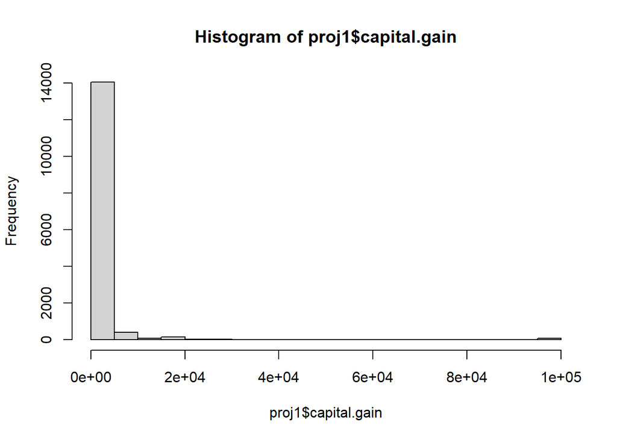

```r
# histogram of capital gain
hist(proj1$capital.gain)
```

The extreme data values in the right tail all have the exact same value: 99999. It is unlikely that all these individuals have the exact same amount of capital gains. Thus it is likely that the 99999 entry is code for missing.

```r
# set 99999 cg to missing value
proj1$capital.gain[proj1$capital.gain == 99999] <- NA

#  mean of capital gain
cgm <- mean(proj1$capital.gain, na.rm = TRUE)
cgm # 603.0878
```

```
## [1] 603.0878
```

```r
# sd of capital gain
cgsd<- sd(proj1$capital.gain, na.rm = TRUE)
cgsd # 2610.7
```

```
## [1] 2610.7
```

```r
# impute missing data into capital gain
imputation_model <-
  preProcess(proj1,
           method = c("knnImpute"))

# new data set with imputed values
proj1.imp  <-
  predict(imputation_model, proj1)

# view results
View(proj1.imp)
```

```r
# Because it is pre-EDA, de-standardize the imputed capital.gain, it is on the original scale, with no missing values, cg.imp

cg.imp<- proj1$cg.imp<-
  ifelse(
   test = is.na(proj1$capital.gain) == TRUE,
  yes = proj1.imp$capital.gain * cgsd + cgm,
  no = proj1$capital.gain)
summary(proj1$cg.imp)
```

```
##    Min. 1st Qu.  Median    Mean 3rd Qu.    Max.
##     0.0     0.0     0.0   605.9     0.0 41310.0
```

```r
table(proj1$cpg.imp)
```

```
## < table of extent 0 >
```

```r
# proj1$cg.imp <- round(proj1.imp$capital.gain * cgsd + cgm, 5)

# new sd with imputed values
sd(proj1$cg.imp) # 2606.436
```

```
## [1] 2606.436
```

```r
#new mean with imputed values
mean(proj1$cg.imp) # 605.9433
```

```
## [1] 605.9433
```

| Capital Gains | Mean | Standard Deviation |
| --- | --- | --- |
| Original | 603.0878 | 2610.7 |
| Imputed | 605.9433 | 2606.436 |

No systematic differences were presented by adding imputed values to the capital.gains field in place of missing data, as the mean and standard deviation between the original capital.gains data and the imputed capital.gains differ by about 1 percent.

```r
# flag variable: cg.miss
# 1 when capital.gain (pre-imputation) is missing
# 0 otherwise

cg.miss =
  proj1$cg.miss <- ifelse(test = is.na(proj1$capital.gain) == TRUE, yes = 1,no = 0)

# contingency table for flag variable capital gains & income
table1 <- table(proj1$income,cg.miss)
table1
```

```
##        cg.miss
##             0     1
##   <=50K 11243     0
##   >50K   3485    69
```

| Capital Gains | Cg.miss |  |
| --- | --- | --- |
| Income | 0 | 1 |
| <= 50k | 11243 | 0 |
| > 50k | 3485 | 69 |

Out of the 69 missing values within the capital.gain field, all missing values are among individuals with an income greater than $50,000. Interestingly, missing values are not split among income levels. Perhaps high income individuals did not want to disclose capital gain.

```r
# create index
ID<- proj1$ID <- 1:nrow(proj1)

# create a new column for marital status
(names(proj1)[names(proj1)=="marital.status"] <- "marital.status.old")
```

```
## [1] "marital.status.old"
```

```r
marital.status<- proj1$marital.status <-
  revalue(proj1$marital.status,
          c("Married-civ-spouse" = 1, "Divorced" =0,
            "Widowed" = 0,
            "Never-married"= 0,
            "Married-AF-spouse"=1,
            "Married-spouse-absent"=1,
            "Separated"=0))

summary(proj1$marital.status)
```

```
##    Length     Class      Mode
##     14797 character character
```

```r
proj1$marital.status <- ifelse(proj1$marital.status== 0, "Other", "Married")
# 0 =  "other"
# 1 = "married"

# contingency table with income and marital status
t1 <- table(proj1$income, proj1$marital.status)
t1 #assign table (rows, column)
```

```
##
##         Married Other
##   <=50K    3923  7320
##   >50K     3058   496
```

```r
#proportions of t1, 2 decimal places
round(prop.table(t1, margin = 2)*100, 2)
```

```
##
##         Married Other
##   <=50K   56.20 93.65
##   >50K    43.80  6.35
```

|  | Martial Status |  |
| --- | --- | --- |
| Income | Married | Other |
| <= 50k | 56.20 | 93.65 |
| > 50k | 43.80 | 6.35 |

There are about 7 times more high income married individuals than high income unmarried individuals. 6.35% of unmarried individuals have an income above $50,000 whereas 43.8% of married individuals have an income over $50,000. Interestingly, a greater proportion of married individuals earn <=50k despite the overwhelming majority of records in the “other” category belonging to <=50k status.

```r
###############

# make capital gain and capital loss one variable

# equal 1 whenever a customer has either any (imputed) capital gains or any capital losses.
# 0 otherwise

capgl<- paste(proj1$capital.loss,proj1$capital.gain)


capgl <- ifelse(capgl>= 1, 1, 0)
# summary
summary(capgl)
```

```
##    Min. 1st Qu.  Median    Mean 3rd Qu.    Max.
## 0.00000 0.00000 0.00000 0.04717 0.00000 1.00000
```

```r
# set as categorical
capgl <- as.factor(capgl)
summary(capgl)
```

```
##     0     1
## 14099   698
```

```r
# table comparing income and capital loss or gain
t2 <- table(proj1$income, capgl)
t2
```

```
##        capgl
##             0     1
##   <=50K 10898   345
##   >50K   3201   353
```

```r
# proportion table with column proportions
round(prop.table(t2, margin = 2)*100, 2)
```

```
##        capgl
##             0     1
##   <=50K 77.30 49.43
##   >50K  22.70 50.57
```

|  | capgl |  |
| --- | --- | --- |
| Income | 0 | 1 |
| <= 50k | 77.30 | 49.43 |
| > 50k | 22.70 | 50.57 |

**Outliers**

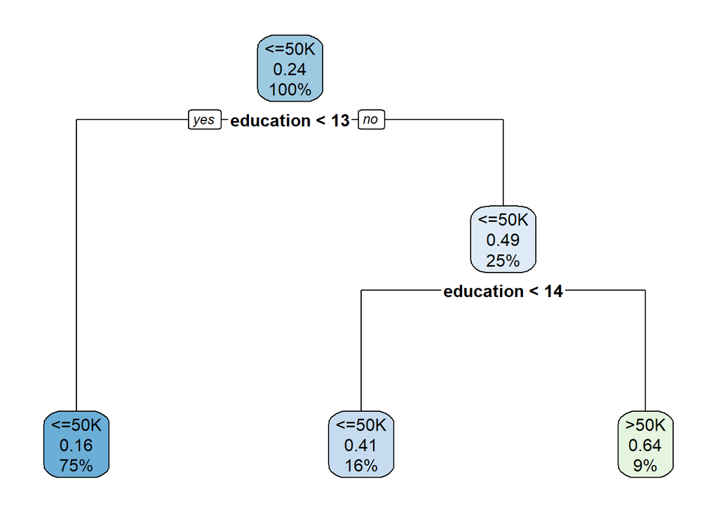

```r
# decision tree for predicting income based on education
eb <- rpart(formula = income ~ education,
                  data = proj1, control = rpart.control
                  (minbucket = .01 * nrow(proj1),
                      maxdepth=2))
                  rpart.plot(eb)
```

```r
 # use cut function, along with the split thresholds from the tree
educ.bin <- cut(proj1$education,
                breaks = c(1, 13, 14, 16))
summary(proj1$educ.bin)
```

```
## Length  Class   Mode
##      0   NULL   NULL
```

```r
## contingency table
## with income for the rows and educ.bin for the columns
t10<-table(proj1$income, educ.bin)
t10
```

```
##        educ.bin
##         (1,13] (13,14] (14,16]
##   <=50K  10760     344     115
##   >50K    2753     444     357
```

```r
#with the column proportions, rounded to two decimal places
round(prop.table(t10, margin = 2)*100, 2)
```

```
##        educ.bin
##         (1,13] (13,14] (14,16]
##   <=50K  79.63   43.65   24.36
##   >50K   20.37   56.35   75.64
```

**Contingency Table of income and education Counts**

[output not shown]

**Contingency Table of income and education with column proportions**

[output not shown]

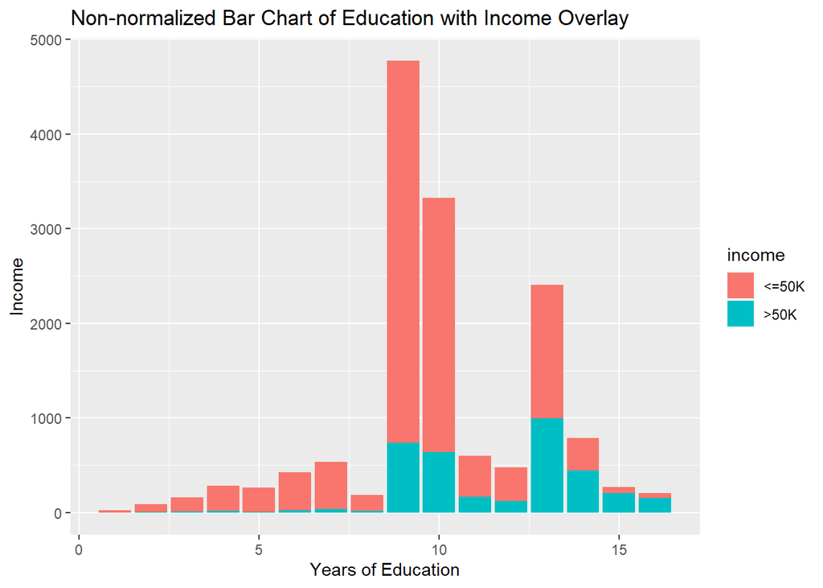

```r
# stacked bar graphs of education with income overlay

    # non-normalized bar chart
        ggplot(proj1, aes(education))+
        geom_bar(aes(fill = income), position = "stack")+
        xlab("Years of Education") + ylab("Income")+
        ggtitle("Non-normalized Bar Chart of Education with Income Overlay")
```

The non-normalized bar graph shows a somewhat-normal distribution and indicates most records indicate years of education between 9 and 10 with a significant number at 13 as well.

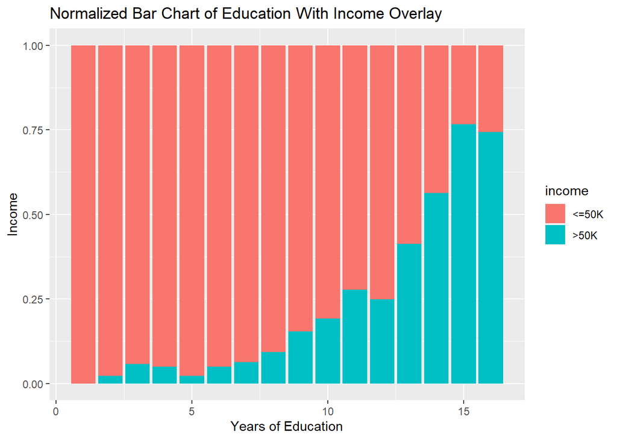

```r
# normalized bar chart
        ggplot(proj1, aes(education))+
        geom_bar(aes(fill = income), position = "fill")+
        xlab("Years of Education") + ylab("Income")+
        ggtitle("Normalized Bar Chart of Education With Income Overlay")
```

The normalized bar graph indicates as years of education increase, records with income > 50k increase, suggesting there is a correlational relationship between education and income.

A normalized bar chart indicates the proportions between predictor and target variables clearly as each of the bars are stretched from 0-1, or 0-100%, regardless of their count, allowing you to see how each bar relates to the overlay value. You can see greater variability within each x value given the y/x proportion/overlay. A non-normalized bar chart is beneficial for seeing overall distribution of the data and the total counts of the bars (y axis value) in each location.

```r
# counts with row and column totals
        # proportions with column totals

#income and education counts with row and column totals

  #income and sex counts with row and column totals
  tab14<- table(proj1$income,proj1$sex)
  tab15 <- addmargins(A = tab14, margin = c(1,2),
                        FUN = sum, quiet = TRUE)
  tab15
```

```
##
##         Female  Male   sum
##   <=50K   4348  6895 11243
##   >50K     564  2990  3554
##   sum     4912  9885 14797
```

```r
  # income and sex column proportions with column totals only
  CP2<- round(prop.table(tab14, margin = 2)*100, 2)
   addmargins(A = CP2, margin = (1),
              FUN = sum, quiet = TRUE)
```

```
##
##         Female   Male
##   <=50K  88.52  69.75
##   >50K   11.48  30.25
##   sum   100.00 100.00
```

**Contingency Table of income and sex Counts with Row and Column Totals**

| Income | Female | Male | Totals |
| --- | --- | --- | --- |
| < = 50k | 4348 | 6895 | 11243 |
| >50k | 564 | 2990 | 3554 |
| Totals | 4912 | 9885 | 14797 |

There are twice as many records of males than records of females, with records of males making up most of the records of both income >50k and income <=50k.

The table of counts is preferable because it shows the distribution of records, with totals indicating there are less records of females than males, therefore we should look to proportions for understanding relationships related to income.

**Contingency Table of income and sex Proportions with Column Totals**

| Income | Female | Male |
| --- | --- | --- |
| < = 50k | 88.52 | 69.75 |
| >50k | 11.48 | 30.25 |
| Totals | 100 | 100 |

The table with column proportions is preferable because it shows the proportions among the certain counts which is a more accurate indicator of a how gender affects income because it is calculated out of 100 for both columns, regardless of their count.